# Switched-capacitor converter

A series-parallel switched-capacitor converter is shown in the figure. The input voltage is $50\,$V, the load resistance is $10\,k\Omega$, and the capacitors are $50\,\mu$F each with an ESR of $0.75\,\Omega$. The clock has a frequency of $50\,$kHz and a duty ratio of $50\,\%$. Determine

1. the output voltage
2. the voltage across each capacitor

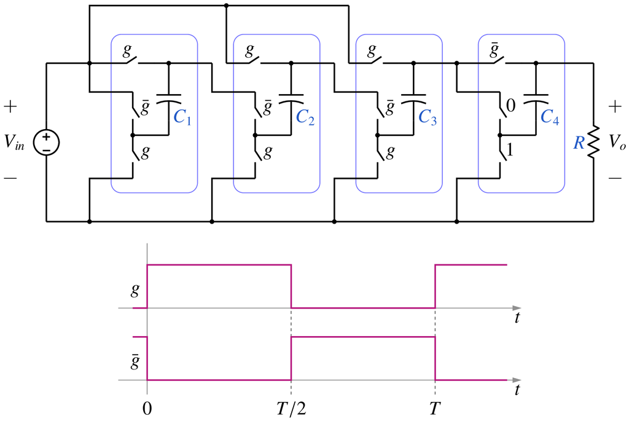

```python
from IPython.display import Image
Image(filename =r'switched_cap_2_fig_1.png', width=600)
```

```python
# run this cell to view the circuit file.
%pycat switched_cap_2_orig.in
```

We now replace the strings such as `\$C` with the values of our choice by running the python script given below. It takes an existing circuit file `switched_cap_2_orig.in` and produces a new circuit file `switched_cap_2.in`, after replacing `\$C` (etc) with values of our choice.

```python
import gseim_calc as calc
import numpy as np

s_C = "50u"
s_f_hz = "50e3"
s_ESR = "0.75"
s_RL = "10k"

l = [
  ('$C', s_C),
  ('$f_hz', s_f_hz),
  ('$ESR', s_ESR),
  ('$RL', s_RL),
]
calc.replace_strings_1("switched_cap_2_orig.in", "switched_cap_2.in", l)
print('switched_cap_2.in is ready for execution')
```

```
switched_cap_2.in is ready for execution
```

```python
import os
import dos_unix
# uncomment for windows:
#dos_unix.d2u("switched_cap_2.in")
os.system('run_gseim switched_cap_2.in')
```

```
Circuit: filename = switched_cap_2.in
main: calling solve_sss
solve_sss starting: sss_n_st: 4
solve_sss_ex: sss_iter_newton=0, rhs_sss_norm=3.1630e-04, sss_period_1_compute=2.0000e-05
solve_sss_ex: sss_iter_newton=1, rhs_sss_norm=7.5984e-16, sss_period_1_compute=2.0000e-05
solve_sss_ex: calling sss_solve_trns_ex for one more trns step
Transient simulation starts...
i=0
GSEIM: Program completed.
```

```
0
```

```
filename: switched_cap_2.dat
average voltage across C1:  4.9970E+01
average voltage across C2:  4.9970E+01
average voltage across C3:  4.9970E+01
average voltage across C4:  1.9980E+02
```

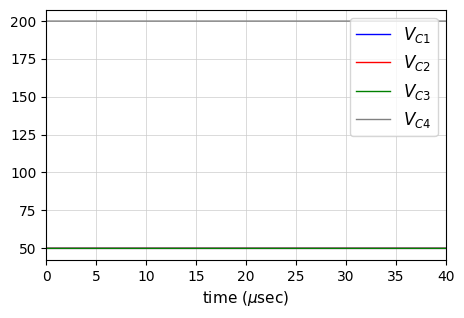

```python
import numpy as np
import matplotlib.pyplot as plt
import gseim_calc as calc
from setsize import set_size

f_hz = float(s_f_hz)
T = 1.0/f_hz

slv = calc.slv("switched_cap_2.in")

i_slv = 0
i_out = 0
filename = slv.l_filename_all[i_slv][i_out]
print('filename:', filename)
u = np.loadtxt(filename)
t = u[:, 0]

v_c1 = slv.get_array_double(i_slv,i_out,"v_c1",u)
v_c2 = slv.get_array_double(i_slv,i_out,"v_c2",u)
v_c3 = slv.get_array_double(i_slv,i_out,"v_c3",u)
v_c4 = slv.get_array_double(i_slv,i_out,"v_c4",u)
i_c1 = slv.get_array_double(i_slv,i_out,"i_c1",u)
i_c2 = slv.get_array_double(i_slv,i_out,"i_c2",u)
i_c3 = slv.get_array_double(i_slv,i_out,"i_c3",u)
i_c4 = slv.get_array_double(i_slv,i_out,"i_c4",u)

v_c1_avg = calc.avg_3(t, v_c1, 0.0, 2.0*T, 1.0e-4*T)
v_c2_avg = calc.avg_3(t, v_c2, 0.0, 2.0*T, 1.0e-4*T)
v_c3_avg = calc.avg_3(t, v_c3, 0.0, 2.0*T, 1.0e-4*T)
v_c4_avg = calc.avg_3(t, v_c4, 0.0, 2.0*T, 1.0e-4*T)

print('average voltage across C1:', "%11.4E"%(v_c1_avg))
print('average voltage across C2:', "%11.4E"%(v_c2_avg))
print('average voltage across C3:', "%11.4E"%(v_c3_avg))
print('average voltage across C4:', "%11.4E"%(v_c4_avg))

color1 = "blue"
color2 = "red"
color3 = "green"
color4 = "grey"

fig, ax = plt.subplots()
plt.subplots_adjust(wspace=0, hspace=0.0)

set_size(4, 2.5, ax)
plt.grid(color='#CCCCCC', linestyle='solid', linewidth=0.5)

ax.set_xlim(left=0.0, right=2.0*T*1e6)

ax.plot(t*1e6, v_c1, color=color1, linewidth=1.0, label="$V_{C1}$")
ax.plot(t*1e6, v_c2, color=color2, linewidth=1.0, label="$V_{C2}$")
ax.plot(t*1e6, v_c3, color=color3, linewidth=1.0, label="$V_{C3}$")
ax.plot(t*1e6, v_c4, color=color4, linewidth=1.0, label="$V_{C4}$")

plt.xlabel('time (' + r'$\mu$' + 'sec)', fontsize=11)

ax.legend(loc = 'upper right',frameon = True, fontsize = 10, title = None,
   markerfirst = True, markerscale = 1.0, labelspacing = 0.5, columnspacing = 2.0,
   prop = {'size' : 12},)

plt.show()
```

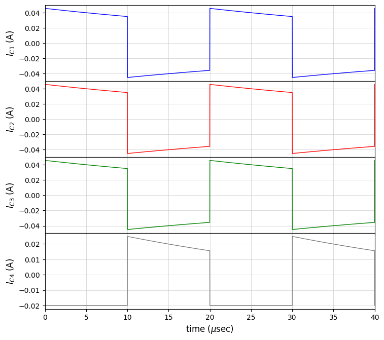

```python
import numpy as np
import matplotlib.pyplot as plt
import gseim_calc as calc
from setsize import set_size

fig, ax = plt.subplots(4, sharex=False)
plt.subplots_adjust(wspace=0, hspace=0.0)

set_size(6.5, 6, ax[0])

for i in range(4):
    ax[i].set_xlim(left=0.0, right=2.0*T*1e6)
    ax[i].grid(color='#CCCCCC', linestyle='solid', linewidth=0.5)

ax[0].set_ylabel(r'$I_{C1}$ (A)', fontsize=12)
ax[1].set_ylabel(r'$I_{C2}$ (A)', fontsize=12)
ax[2].set_ylabel(r'$I_{C3}$ (A)', fontsize=12)
ax[3].set_ylabel(r'$I_{C4}$ (A)', fontsize=12)

for k in range(3):
    ax[k].tick_params(labelbottom=False)

color1 = "blue"

ax[0].plot(t*1e6, i_c1, color=color1, linewidth=1.0)
ax[1].plot(t*1e6, i_c2, color=color2, linewidth=1.0)
ax[2].plot(t*1e6, i_c3, color=color3, linewidth=1.0)
ax[3].plot(t*1e6, i_c4, color=color4, linewidth=1.0)

ax[3].set_xlabel(r'time ($\mu$sec)', fontsize=12)

plt.show()
```

This notebook was contributed by **Prof. Nakul Narayanan K**, Govt. Engineering College, Thrissur. He may be contacted at nakul@gectcr.ac.in.